# Detailed Insights: South Africa

## Welcome!

You have reached the CCN Inventory Tool Detailed Insights Report.

Congratulations! This geography has available data.

Potential data availability within the Inventory Tool ranges from Tier I, Tier II, or Tier III Carbon stock estimates.

This document includes country-specific insights and more detailed analysis, including carbon stocks, emissions factors, and ecosystem wetland area for mangrove, marsh, and seagrass habitats. This report details information for the selected geography, **South Africa**.

Explore the rest of the dashboard for more exciting visualizations, map features and data.

Resources referenced to calculate estimates for **South Africa** are listed below under ‘References’ at the end of this document.

If you have any questions or data you would like to add to the Coastal Carbon Network, please reach out to us at CoastalCarbon@si.edu.

## Total Carbon Stock Estimates

Total Carbon stock estimates were calculated for each geography in total, and for mangrove, tidal marsh, and seagrass habitats when available.

We estimate that **South Africa** contains a mean estimate of 2.67714^{6} metric tonnes soil Carbon.

We estimate that **South Africa** contains between 3.40887^{6} to 1.9454^{6} metric tonnes of soil C to a depth of 1 m, with a mean estimate of 2.67714^{6} metric tonnes C.

Total Geography Level Carbon Stocks

[output not shown]

This total estimate includes total mangrove soil carbon stocks, with a mean estimate of 1.6131^{5} metric tonnes of soil C to a depth of 1 meter.

We estimate seagrass soil carbon stocks for **South Africa** to have a mean estimate of 4.115124^{6}

## Wetland Areas and Activities

We estimate mangrove area in **South Africa** to be 1188 to 1568 hectares, with a mean estimate of 1353 hectares according to Global Mangrove Watch Bunting et al. (2018).

We estimate seagrass area to be **South Africa** to be a mean of 3.81^{4} hectares, according to McKenzie et al. (2020), which aggregates global seagrass data from a number of sources.

## Calculated Stocks and Emissions Factors

This section of the report details whether data is available to estimate Tier I, Tier II, or Tier III value estimates for tidal marsh, mangrove, and seagrass ecosystems in **South Africa**.

If data for the selected country is available in the Coastal Carbon Atlas, we have applied a Tier II emission factor based on a simple average of country specific data queried from the Atlas.

Data from **South Africa** included in the Coastal Carbon Atlas consists of 253 soil profiles from 21 watersheds. This data comes from 2 distinct habitat type(s).

In the case that there is not yet any country specific information in the Coastal Carbon Atlas, we instead applied IPCC Tier I estimate. IPCC Tier I estimates for mangrove, marsh, and seagrass ecosystems are listed below.

The table in this section also details whether the calculated Tier II value is significantly different from the estimated Tier I values. This is observed in the “Overlap” column.

IPCC Tier I Value Estimates

| Habitat | Mean | Lower_CI | Upper_CI |
| --- | --- | --- | --- |
| mangrove | 386 | 351 | 424 |
| marsh | 255 | 254 | 297 |
| seagrass | 108 | 84 | 139 |

## Data Availiability by Tier

Availiability of Tier I and Tier II Data

[output not shown]

### Tier I Carbon Stocks

This section includes Tier I Carbon Stocks included for **South Africa**. In the case that all habitats; mangrove, tidal marsh, and seagrass have availiable Tier II estimates, please refer to Table 2: IPCC Tier I Value Estimates for applicable Tier I values.

Tier I Carbon Stock Estimates

| Country | Territory | Habitat | Mean Stock (MgHa) | Lower CI | Upper CI |
| --- | --- | --- | --- | --- | --- |
| South Africa | South Africa | marsh | 255 | 254 | 297 |
| South Africa | South Africa | seagrass | 108 | 84 | 139 |

### Tier II Carbon Stocks

This table includes Tier II Carbon Stock estimates for **South Africa**. Estimates in this table were derived from data queried from the Coastal Carbon Atlas.

A selected country may have available Tier II values for one or multiple habitats, this is dependent on core data accessible through the Coastal Carbon Atlas. At the time of analysis, referencing Version 1.5.0, **South Africa** represents a total of 253 cores across 2 distinct habitats.

Tier II Carbon Stock Estimates

| Country | Territory | Habitat | Mean Stock (MgHa) | Lower CI | Upper CI | Standard Error |
| --- | --- | --- | --- | --- | --- | --- |
| South Africa | South Africa | mangrove | 119 | 83.3 | 155 | 18.32378 |

### Tier III Carbon Stocks

Tier III carbon stocks were estimated, when available, from remote sensing data from Maxwell et al 2021 and Sanderman et al 2018. The table below details whether estimated values are available for **South Africa**, and any overlap with associated Tier I or Tier II values.

If there are no Tier III estimates associated with the selected country and specific habitat of interest, please refer to above Tier I and Tier II tables.

Tier III Carbon Stock Estimates

| Country | Territory | Habitat | Mean Stock (MgHa) | Lower CI | Upper CI |
| --- | --- | --- | --- | --- | --- |
| South Africa | South Africa | mangrove | 239 | 196 | 282 |

In the selected geography, South Africa ,Tier III estimated stock MgHa values are greater than Tier II values estimated from Coastal Carbon Atlas Data. In this case, the Tier III Remote-sensing esimate is significantly greater than country-specific average. Additionally, estimated Tier III stock values derived from remote sensing are less than estimates Tier I values. In this case, the Tier III Remote-sensing esimate is significantly less than Tier I estimate.

## Visualizations

### 1. Data Metrics

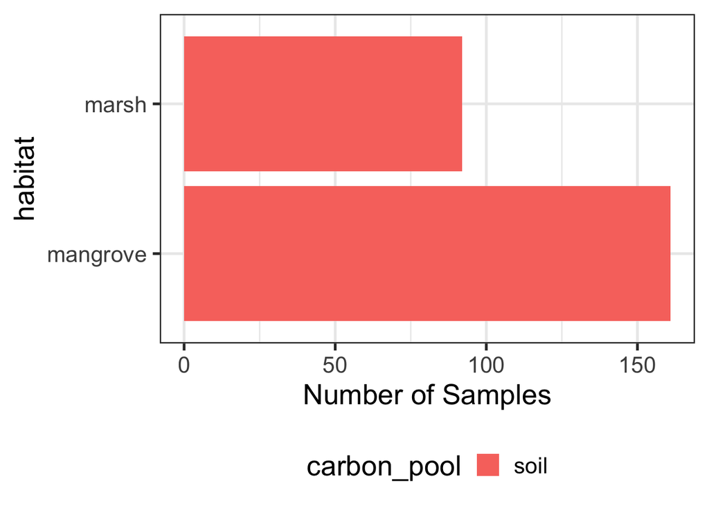

### 2. Emissions Factors

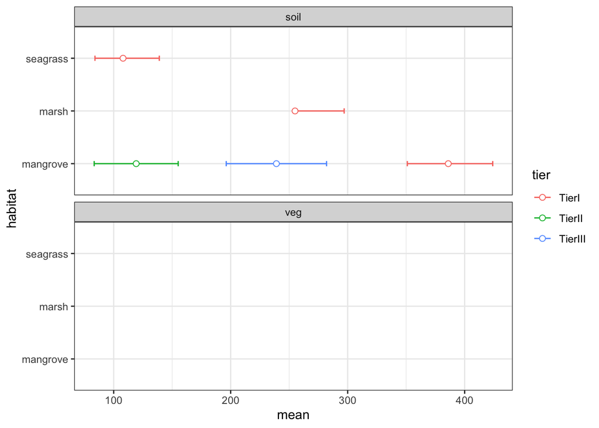

### 3. Activity Data

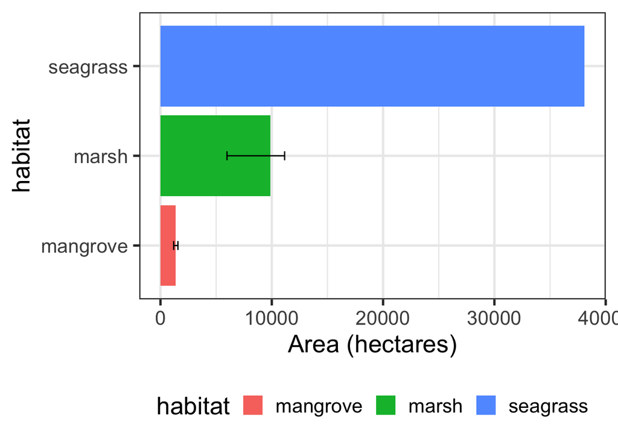

## References

2019. *Standard Theses*.

Adams, J. B., and L. R. D. Human. 2016. “Investigation into the Mortality of Mangroves at St. Lucia Estuary.” *South African Journal of Botany*. https://doi.org/http://dx.doi.org/10.1016/j.sajb.2016.03.018.

Bekker, Zandri. 2015a. *Standard Theses*.

———. 2015b. *Standard Theses*.

Bezuidenhout, Chantel. 2011. “MACROPHYTES AS INDICATORS OF PHYSICO-CHEMICAL FACTORS IN SOUTH AFRICAN ESTUARIES.” *Standard Theses*.

Brown, Catherine E., and Anusha Rajkaran. 2020b. “The Phylogeography, Biomass Allocation and Phenology of Salicornia Tegetaria (s. Steffen, Mucina & g. Kadereit) Piirainen & g. Kadereit, an Endemic Salt Marsh Species in South Africa.” *Standard Theses*. https://etd.uwc.ac.za/xmlui/handle/11394/6391.

———. 2020a. “The Phylogeography, Biomass Allocation and Phenology of Salicornia Tegetaria (s. Steffen, Mucina & g. Kadereit) Piirainen & g. Kadereit, an Endemic Salt Marsh Species in South Africa.” *Standard Theses*. https://etd.uwc.ac.za/xmlui/handle/11394/6391.

———. 2020c. “The Phylogeography, Biomass Allocation and Phenology of Salicornia Tegetaria (s. Steffen, Mucina & g. Kadereit) Piirainen & g. Kadereit, an Endemic Salt Marsh Species in South Africa.” *Standard Theses*. https://etd.uwc.ac.za/xmlui/handle/11394/6391.

Bunting, Pete, Ake Rosenqvist, Richard M. Lucas, Lisa-Maria Rebelo, Lammert Hilarides, Nathan Thomas, Andy Hardy, Takuya Itoh, Masanobu Shimada, and C. Max Finlayson. 2018. “The Global Mangrove Watch—a New 2010 Global Baseline of Mangrove Extent.” *Remote Sensing* 10 (10): 1669. https://doi.org/10.3390/rs10101669.

Els, Jessica. 2017. “Carbon Storage of Zostera Capensis in the Knysna Estuary.” *Standard Theses*.

———. 2019b. “Carbon and Nutrient Storage of the Swartkops Estuary Salt Marsh and Seagrass Habitats.” *Standard Theses*.

———. 2019a. “Carbon and Nutrient Storage of the Swartkops Estuary Salt Marsh and Seagrass Habitats.” *Standard Theses*.

Geldenhuys, Chanel, Phumlile Cotiyane, and Anusha Rajkaran. 2016. “Understanding the Creek Dynamics and Environmental Characteristics That Determine the Distribution of Mangrove and Salt Marsh Communities at Nahoon Estuary.” *South African Journal of Botany*. https://doi.org/http://dx.doi.org/10.1016/j.sajb.2016.04.013.

Hoppe-Speer, SCL, JB Adams, and A Rajkaran. 2013. “Response of Mangroves to Drought and Non-Tidal Conditions in St Lucia Estuary, South Africa.” *African Journal of Aquatic Science*. https://doi.org/https://doi.org/10.2989/16085914.2012.759095.

Human, Lucienne R. D., Jessica Els, Johan Wasserman, and Janine B. Adams. 2022. “Blue Carbon and Nutrient Stocks in Salt Marsh and Seagrass from an Urban African Estuary.” *Science of the Total Environment*. https://doi.org/http://dx.doi.org/10.1016/j.scitotenv.2022.156955.

Johnson, Jaime L., Jacqueline L. Raw, and Janine B. Adams. 2020. “First Report on Carbon Storage in a Warm-Temperate Mangrove Forest in South Africa.” *Estuarine, Coastal and Shelf Science*. https://doi.org/https://doi.org/10.1016/j.ecss.2019.106566.

Lemley, Daniel Allen. 2018a. “ESTUARINE MICROALGAL BLOOM DYNAMICS AT MULTIPLE TEMPORAL SCALES.” *Standard Theses*.

———. 2018b. “ESTUARINE MICROALGAL BLOOM DYNAMICS AT MULTIPLE TEMPORAL SCALES.” *Standard Theses*.

Matabane, Rebotile. 2018. “Tolerance of Salt Marsh Ecotone Species to Salinity and Inundation.” *Standard Theses*.

Maxwell, Tania L., Andr’e S. Rovai, Maria Fernanda Adame, Janine B. Adams, Jos’e ’Alvarez-Rogel, William E. N. Austin, Kim Beasy, Francesco Boscutti, Michael E. Böttcher, Tjeerd J. Bouma, Richard H. Bulmer, Annette Burden, Shannon A. Burke, Saritta Camacho, Doongar R. Chaudhary, Gail L. Chmura, Margareth Copertino, Grace M. Cott, Christopher Craft, John Day, Carmen B. de los Santos, Lionel Denis, et al. 2023. “Global Dataset of Soil Organic Carbon in Tidal Marshes.” *Scientific Data* 10 (1). https://doi.org/10.1038/s41597-023-02633-x.

Maxwell, Tania L., Andr’e S Rovai, Maria Fernanda Adame, Janine B. Adams, Jos’e ’Alvarez-Rogel, William E. N. Austin, Kim Beasy, Francesco Boscutti, Michael E. Böttcher, Tjeerd Joris Bouma, Richard H. Bulmer, Annette Burden, Shannon A. Burke, Saritta Camacho, Doongar Chaudhary, Gail L. Chmura, Margareth Copertino, Grace M. Cott, Christopher Craft, John Day, Carmen B. de los Santos, Weixin Ding, et al. 2023. “Database: Tidal Marsh Soil Organic Carbon (MarSOC) Dataset.” Zenodo. https://doi.org/10.5281/ZENODO.8414110.

Mbense, S., A. Rajkaran, U. Bolosha, and J. Adams. 2016b. “Rapid Colonization of Degraded Mangrove Habitat by Succulent Salt Marsh.” *South African Journal of Botany*. https://doi.org/http://dx.doi.org/10.1016/j.sajb.2016.06.011.

———. 2016a. “Rapid Colonization of Degraded Mangrove Habitat by Succulent Salt Marsh.” *South African Journal of Botany*. https://doi.org/http://dx.doi.org/10.1016/j.sajb.2016.06.011.

McKenzie, Len J, Lina M Nordlund, Benjamin L Jones, Leanne C Cullen-Unsworth, Chris Roelfsema, and Richard K F Unsworth. 2020. “The Global Distribution of Seagrass Meadows.” *Environmental Research Letters* 15 (7): 074041. https://doi.org/10.1088/1748-9326/ab7d06.

Naidoo, Lyndle. 2014. “Vegetation and Sediment Characteristics of the Salt Marshes of the Duiwenhoks Estuary.” *Standard Theses*.

Naidoo, and G. 1980. “Mangrove Soils of the Beachwood Area, Durban.” *Journal of South African Botany*.

Naidoo, G, Raiman, and F. 1982. “Some Physical and Chemical Properties of Mangrove Soils at Sipingo and Mgeni, Natal.” *South African Journal of Botany*.

Peer, N, A Rajkaran, NAF Miranda, RH Taylor, B Newman, F Porri, JL Raw, SP Mbense, and JB Adams & R Perissinotto. 2018. “Latitudinal Gradients and Poleward Expansion of Mangrove Ecosystems in South Africa: 50 Years After Macnae’s First Assessment.” *African Journal of Marine Science*. https://doi.org/https://doi.org/10.2989/1814232X.2018.1466728.

Rajkaran, Anusha. 2011b. “A Status Assessment of Mangrove Forests in South Africa and the Utilization of Mangroves at Mngazana Estuary (PhD Disseration).” *Standard Theses*.

———. 2011a. “A Status Assessment of Mangrove Forests in South Africa and the Utilization of Mangroves at Mngazana Estuary (PhD Disseration).” *Standard Theses*.

Rautenbach, Kelly. 2015. “PRESENT STATE OF MACROPHYTES AND RESPONSES TO MANAGEMENT SCENARIOS AT THE ST. LUCIA AND MFOLOZI ESTUARIES.” *Standard Theses*.

Raw, J. L., C. L. Julie, and J. B. Adams. 2019. “A Comparison of Soil Carbon Pools Across a Mangrove-Salt Marsh Ecotone at the Southern African Warm-Temperate Range Limit.” *South African Journal of Botany*. https://doi.org/https://doi.org/10.1016/j.sajb.2019.11.005.

Raw, JL, T Riddin, J Wasserman, TWK Lehman, TG Bornman, and JB Adams. 2020. “Salt Marsh Elevation and Responses to Future Sea-Level Rise in the Knysna Estuary, South Africa.” *African Journal of Aquatic Science* 45 (1–2): 49–64. https://doi.org/10.2989/16085914.2019.1662763.

Sanderman, Jonathan. 2017a. “Global Mangrove Soil Carbon: Dataset and Spatial Maps.” Harvard Dataverse. https://doi.org/10.7910/dvn/ocyuit.

———. 2017b. “Global Mangrove Soil Carbon: Dataset and Spatial Maps.” Harvard Dataverse. https://doi.org/10.7910/dvn/ocyuit.

UNEP-WCMC, and FT Short. 2018. “Global Distribution of Seagrasses (Version 6.0).” UN Environment Programme World Conservation Monitoring Centre. https://wedocs.unep.org/bitstream/handle/20.500.11822/34031/GDS.pdf?sequence=1&isAllowed=y.

Veldkornet, D. A., A. J. Potts, and J. B. Adams. 2016. “The Distribution of Salt Marsh Macrophyte Species in Relation to Physicochemical Variables.” *South African Journal of Botany*. https://doi.org/http://dx.doi.org/10.1016/j.sajb.2016.08.008.

Veldkornet, Dimitri. 2016a. “Estuarine Species and Habitats: Distribution and Connectivity.” *Standard Theses*.

———. 2016b. “Estuarine Species and Habitats: Distribution and Connectivity.” *Standard Theses*.

Verl’e, and K. 2013. “Characteristics of the Mbashe Catchment and Estuary, South Africa. Towards an Assessment of Catchment Land Use Impact.” *Standard Theses*. https://documentatiecentrum.watlab.be/imis.php?module=ref&refid=247682.

Vromans, Deborah Claire. 2010. “MACROPHYTE PHENOLOGY IN a TEMPORARILY OPEN/CLOSED ESTUARY COMPARED WITH a PERMANENTLY OPEN ESTUARY.” *Standard Theses*.

Wooldridge, T. H., J. B. Adams, and M. Fernandes. 2016. “Biotic Responses to Extreme Hypersalinity in an Arid Zone Estuary, South Africa.” *South African Journal of Botany*. https://doi.org/http://dx.doi.org/10.1016/j.sajb.2016.05.004.

Worthington, Thomas A., Mark Spalding, Emily Landis, Tania L. Maxwell, Alejandro Navarro, Lindsey S. Smart, and Nicholas J. Murray. 2024. “The Distribution of Global Tidal Marshes from Earth Observation Data.” *Global Ecology and Biogeography* 33 (8). https://doi.org/10.1111/geb.13852.